# Avian seed dispersal may be insufficient for plants to track future temperature change on tropical mountains - Nowak - - Global Ecology and Biogeography - Wiley Online Library

[Global Ecology and Biogeography](https://onlinelibrary.wiley.com/journal/14668238)

[Early View](https://onlinelibrary.wiley.com/toc/14668238/0/0)

[figure not shown]

RESEARCH ARTICLE

Open Access

# Avian seed dispersal may be insufficient for plants to track future temperature change on tropical mountains

[Larissa Nowak](https://onlinelibrary.wiley.com/action/doSearch?ContribAuthorRaw=Nowak%2C+Larissa),

[Matthias Schleuning](https://onlinelibrary.wiley.com/action/doSearch?ContribAuthorRaw=Schleuning%2C+Matthias),

[Irene M. A. Bender](https://onlinelibrary.wiley.com/action/doSearch?ContribAuthorRaw=Bender%2C+Irene+M+A),

[Katrin Böhning-Gaese](https://onlinelibrary.wiley.com/action/doSearch?ContribAuthorRaw=B%C3%B6hning-Gaese%2C+Katrin),

[D. Matthias Dehling](https://onlinelibrary.wiley.com/action/doSearch?ContribAuthorRaw=Dehling%2C+D+Matthias),

[Susanne A. Fritz](https://onlinelibrary.wiley.com/action/doSearch?ContribAuthorRaw=Fritz%2C+Susanne+A),

[W. Daniel Kissling](https://onlinelibrary.wiley.com/action/doSearch?ContribAuthorRaw=Kissling%2C+W+Daniel),

[Thomas Mueller](https://onlinelibrary.wiley.com/action/doSearch?ContribAuthorRaw=Mueller%2C+Thomas),

[Eike Lena Neuschulz](https://onlinelibrary.wiley.com/action/doSearch?ContribAuthorRaw=Neuschulz%2C+Eike+Lena),

… See all authors

First published: 23 February 2022

https://doi.org/10.1111/geb.13456

## Abstract

### Aim

Climate change causes shifts in species ranges globally. Terrestrial plant species often lag behind temperature shifts, and it is unclear to what extent animal-dispersed plants can track climate change. Here, we estimate the ability of bird-dispersed plant species to track future temperature change on a tropical mountain.

### Location

Tropical elevational gradient (500–3500 m.a.s.l.) in the Manú biosphere reserve, Peru.

### Time period

From 1960–1990 to 2061–2080.

### Taxa

Fleshy-fruited plants and avian frugivores.

### Methods

Using simulations based on the functional traits of avian frugivores and fruiting plants, we quantified the number of long-distance dispersal (LDD) events that woody plant species would require to track projected temperature shifts on a tropical mountain by the year 2070 under different greenhouse gas emission scenarios [representative concentration pathway (RCP) 2.6, 4.5 and 8.5]. We applied this approach to 343 bird-dispersed woody plant species.

### Results

Our simulations revealed that bird-dispersed plants differed in their climate-tracking ability, with large-fruited and canopy plants exhibiting a higher climate-tracking ability. Our simulations also suggested that even under scenarios of strong and intermediate mitigation of greenhouse gas emissions (RCP 2.6 and 4.5), sufficient upslope dispersal would require several LDD events by 2070, which is unlikely for the majority of woody plant species. Furthermore, the ability of plant species to track future changes in temperature increased in simulations with a low degree of trait matching between plants and birds, suggesting that plants in generalized seed-dispersal systems might be more resilient to climate change.

### Main conclusion

Our study illustrates how the functional traits of plants and animals can inform predictive models of species dispersal and range shifts under climate change and suggests that the biodiversity of tropical mountain ecosystems is highly vulnerable to future warming. The increasing availability of functional trait data for plants and animals globally will allow parameterization of similar models for many other seed-dispersal systems.

## 1 INTRODUCTION

Climate change is causing a rapid redistribution of biodiversity globally (Pecl et al., 2017), with species shifting towards higher latitudes and elevations as they track suitable climatic conditions (Feeley et al., 2011; Lenoir et al., 2020). However, species are expected to differ widely in their ability to track suitable climatic conditions, depending on both their traits and the characteristics of the environment (Lenoir et al., 2020). Among terrestrial plants, recent range shifts appear to be lagging behind changes in temperature (Feeley et al., 2011; Lenoir et al., 2020), raising the risk that plant species will be unable to shift their ranges sufficiently fast to reach suitable climates. However, quantitative estimates of the ability of plant species to keep pace with climate change are rare (but see, e.g., González-Varo et al., 2017; González-Varo, Rumeu, et al., 2021; Naoe et al., 2016).

A key challenge in refining projections of species range shifts under climate change lies in quantifying species dispersal ability (Brooker et al., 2007; Williams & Blois, 2018). However, empirical dispersal estimates remain unavailable for many plant species (Chen et al., 2019). One possible way forward is to estimate the dispersal ability based on species traits (Sorensen et al., 2020). For instance, seed-dispersal distances are often positively related to plant height and vary with seed size and dispersal agent (González-Varo et al., 2017; Thomson et al., 2011). However, trait-based approaches to model the dispersal of plants need to account for the complexity of the dispersal process. This applies especially to tropical ecosystems, where most woody plant species depend on animals, particularly birds, for their dispersal (Chen et al., 2017; Jordano, 2014; Rogers et al., 2021).

Fleshy-fruited plants and avian frugivores are linked in complex seed-dispersal networks. In such networks, the dispersal ability of plants is expected to depend on traits in two key ways. First, the degree of trait matching (i.e., the compatibility) between species influences the identity of the bird species with which a plant interacts and the strength of these interactions (Dehling, Töpfer, et al., 2014; Wheelwright, 1985). For instance, interaction probabilities vary as a function of the height of a plant and avian wing pointedness (Bender et al., 2018), a morphological measure tightly linked to flight ability (Sheard et al., 2020). In addition to the differentiation among foraging strata, the bill width determines the fruit size a bird species can efficiently handle and swallow and influences the niche partitioning between large and small frugivores (Bender et al., 2018; Wheelwright, 1985). In empirical seed-dispersal networks, the degree of trait matching (i.e., how closely the trait values of two interacting species match) varies at both small and large spatial scales (Dalsgaard et al., 2017; Menke et al., 2012), probably reflecting the varying flexibility of frugivores in switching between different types of fruit resources (Bender et al., 2017, 2018). Second, the distance that a seed is dispersed depends on the traits of the dispersal agent. For example, larger bird species move farther and retain seeds in the gut for longer, thus leading to longer dispersal distances (Jordano et al., 2007; Sorensen et al., 2020; Westcott & Graham, 2000). Therefore, functional traits can be used to quantify and compare the dispersal ability of bird-dispersed plants because traits determine both the identity of avian dispersers and the seed-dispersal distances provided to plants (Pires et al., 2018, Schleuning et al., 2020).

Here, we integrate two recently developed trait-based models (Figure 1a,b) to estimate the extent to which bird-dispersed plants are able to track projected shifts in suitable climate under different future greenhouse gas emission scenarios (Figure 1c). First, we apply a trait-based interaction model to simulate seed-dispersal interactions between plant and bird species (Donoso et al., 2017; Fründ et al., 2016; Figure 1a), considering different degrees of trait matching between birds and plants. Second, we apply a trait-based seed-dispersal model based on allometric scaling relationships between avian body mass, gut passage time and flight speed to estimate dispersal distances and quantify the long-distance dispersal (LDD) of each plant species (Sorensen et al., 2020; Figure 1b). Finally, to compare in a simple and tractable way the estimated LDD of a plant species with the distance that temperatures are projected to shift vertically (Figure 1c), we quantify the number of LDD events a plant species would require to track projected temperature change by 2070 (Figure 1d).

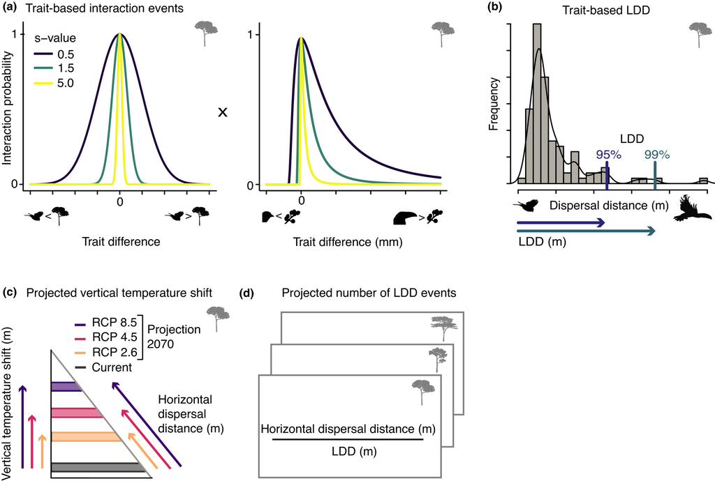

**FIGURE 1**

Trait-based projections of the number of long-distance dispersal (LDD) events. (a) Trait matching, considering two pairs of plant and bird traits (i.e., between plant height and wing pointedness and between fruit width and bill width), informed simulations of seed-dispersal interaction probabilities (Donoso et al., 2017; Fründ et al., 2016). The degree of trait matching was varied according to a trait-matching parameter (*s*-value, with three settings as shown in the key); plant height and wing pointedness were centred and scaled before the simulation. (b) Simulations of dispersal distance are based on allometric relationships of the gut passage time and the flight speed, whereby dispersal distance is positively related to avian body mass (Sorensen et al., 2020). We simulated a dispersal distance for each interaction event between a bird and a plant species and considered the 95th and 99th percentiles of the frequency distribution of all dispersal distances as two alternative proxies for the LDD of that plant species (LDD<sub>95</sub> and LDD<sub>99</sub>, respectively). (c) The projected vertical temperature shift estimates the distance by which the current realized temperature range of a plant species along an elevational gradient is projected to shift vertically (Nowak et al., 2019). Here, we estimated projected vertical temperature shifts until 2070 for three representative concentration pathways (RCPs) representing a strong mitigation (RCP 2.6), a moderate mitigation (RCP 4.5) and a high-emissions scenario (RCP 8.5). We computed the required horizontal dispersal distance as the vertical temperature shift (in metres) divided by the sine of the mean slope (in degrees). (d) The number of LDD events that a plant species requires to track projected vertical temperature shifts by 2070 can be estimated as the ratio of the required horizontal dispersal distance and the simulated LDD of that plant species

With this new integrative simulation approach, we assess the climate-tracking ability of 343 bird-dispersed, woody plant species along a tropical elevational gradient in the Andes of south-east Peru. We evaluate (1) how the projected number of LDD events required by 2070 would vary with the degree of trait matching and (2) to what extent the projected number of LDD events required by 2070 would differ among plant species with different traits. Our first hypothesis is that plant species require fewer LDD events to fully track the projected upslope shifts of their realized temperature niche in generalized seed-dispersal systems with a low degree of trait matching because seed-dispersal distances are likely to be larger in such systems (Sorensen et al., 2020). Our second hypothesis is that large-fruited species require fewer LDD events than small-fruited species because large-fruited species interact preferentially with large-billed and large-sized frugivores that disperse seeds farther (Burns, 2013; Jordano et al., 2007). A similar mechanism might apply to canopy plants if canopy foragers disperse seeds farther.

## 2 METHODS

To identify bird-dispersed woody plant species occurring along the Manú gradient, all plants with ripe fleshy fruits were collected within an area of 1 ha (divided into 10 plots of 20 m × 50 m) located at seven elevations every 500 m.a.s.l. (distances between the plots were ≥200 m; Dehling, Töpfer, et al., 2014). In the field, the plants were identified as morphospecies. Samples of each were taken and identified to species level with specimens from local herbaria. Each site was sampled once in the rainy season (December–March) and once in the dry season (June–September) between December 2009 and September 2011. The resulting plant species pool comprised 343 bird-dispersed woody plant species. This included all woody species that were identified to species level and for which trait and elevation data were available (Supporting Information Table S1). We derived the current minimum and maximum elevation of the plant species across Peru at an elevational resolution of 500 m from the literature (Brako & Zarucchi, 1993), supplemented by data from the Tropicos website ([www.tropicos.org](http://www.tropicos.org/), 2017; for *c*. 3% of the analysed species).

We considered 219 frugivorous bird species that occur along the Manú gradient and consume fruits as a main part of their diet (Supporting Information Table S2; Dehling, Töpfer, et al., 2014). This species pool excluded ground dwellers (the families Tinamidae, Odontophoridae and Psophidae, and the genus *Mitu*) because they have a distinct movement behaviour. It also excluded the few seasonal migrants that are not present year-round (*Catharus ustulatus*, *Elaenia parvirostris*, *Elaenia spectabilis*, *Elaenia strepera*, *Piranga rubra*, *Turdus amaurochalinus*, *Tyrannus savanna* and *Tyrannus tyrannus*). The current minimum and maximum elevations of each bird species along the Manú gradient at an elevational resolution of 50 m were derived from local checklists supplemented by field observations (Dehling et al., 2013; Walker et al., 2006). Elevational ranges were derived from year-round observations and thus account for elevational movements of bird species over the year. Although models of species interactions would ideally also include information on plant and bird abundance, these data are not available for the species along the elevation gradient.

### 2.3 Morphological traits of birds and plants

We compiled data on bird wing pointedness, bill width and body mass and on plant height and fruit width for all species considered in our study (Supporting Information Tables S1 and S2). For both matching trait pairs considered here (i.e., plant height and wing pointedness, and bill width and fruit width), previous studies have reported a positive relationship in seed-dispersal networks (Bender et al., 2018; Dehling, Töpfer, et al., 2014). The focus on fruit rather than seed traits is justified because fruits are the principal handling units of frugivores, as shown in previous work (Muñoz et al., 2016). Moreover, fruit size and seed size are positively related in Neotropical forests (Wright et al., 2007). In our models, we were not able to account for other matching traits, such as those related to fruit content and avian physiology (Herrera, 1982), because such trait data are not available for our study system.

Wing pointedness [hand-wing index, i.e., Kipp's distance (in millimetres) divided by wing length (in millimetres)] and bill width (in millimetres) were measured on museum specimens following measurement protocols from Eck et al. (2011). Measurements were based on at least two females and two males per species (Dehling, Fritz, et al., 2014). Given that body mass influences avian movement (Jordano et al., 2007; Westcott & Graham, 2000), we also compiled data on avian body mass from the literature (Dunning, 2007; Supporting Information Table S2). Plant height (in metres) was measured as the distance from the ground to the top of the plant during the field surveys on all individuals in the plots (Bender et al., 2018; Dehling, Töpfer, et al., 2014; Supporting Information Table S1). Fruit width (in millimetres) was measured on fruits collected during the field surveys, on 20 fruits per plant species. Plant height and fruit width exhibited a weak positive correlation (*n* = 343 species, *r* = .36, *p* < .001).

To test whether the projected number of LDD events until 2070 differs among plant species with different traits, we grouped the plant species into small-fruited versus large-fruited species. We considered plant species within the smallest quartile of fruit width as small fruited (≤4.99 mm) and the species within the largest quartile of fruit width as large fruited (≥11.41 mm). Likewise, we grouped plants into understorey and canopy species, considering plant species within the smallest quartile of plant height as understorey species (≤3.29 m) and the species within the largest quartile of plant height as canopy species (≥9.62 m).

In all analyses, we used species means of plant and bird traits. For one plant species, we had to use trait values from Ecuador (Quitián et al., 2019), and for 20 plant species (*c*. 6% of the species pool), we used mean trait values at the genus level because species-level trait values were unavailable (Supporting Information Table S1). Interspecific trait variation was large (e.g., bill width varied from 5.12 to 38.76 mm, and fruit width varied from 0.5 to 38.4 mm). Therefore, we expect intraspecific trait variation to be of negligible relevance for our simulation study.

### 2.4 Trait-based interaction probabilities and interaction events

With a trait-based interaction model, we computed interaction probabilities between all 219 bird and 343 plant species based on the matching between plant height and wing pointedness and between fruit width and bill width (Figure 1a; Supporting Information Figures S1 and S2). We computed interaction probabilities separately for the two pairs of matching traits and then multiplied the two matrices to yield a matrix of interaction probability between each plant and bird species. This modelling approach reflects the consecutive processes of avian plant choice and fruit handling in the wild.

The trait-matching parameter *s* can be varied and accounts for the fact that fruit and bill width do not need to match perfectly for an interaction to occur (see Supporting Information Figure S1). This also entails that the model can be adjusted to simulate seed-dispersal events in seed-dispersal networks with different degrees of specialization (Figure 1a; Donoso et al., 2017). We considered three trait-matching parameter values representing a low, an intermediate and a high degree of trait matching (*s* = 0.5, 1.5 and 5.0, respectively). Varying this parameter resulted in a low, an intermediate and a high degree of network specialization (*H*<sub>2</sub>’ = .1, .31 and .75, respectively). This covers the range of specialization of empirical seed-dispersal networks, most of which show an intermediate degree of network specialization (Dalsgaard et al., 2017; Dugger et al., 2019).

To account for species co-occurrences along the elevational gradient, we multiplied the matrix of the interaction probabilities by a matrix of co-occurrences of the bird and the plant species. We considered an overlap of the current elevational ranges of plant and bird species along the Manú gradient as co-occurrence and thus prevented interaction links between species that do not co-occur along the gradient. Considering the entire elevational range of plant and bird species also allows rare interaction events between plant and bird species at their elevational range margins, which might be important for rare long-distance dispersal events. To simulate interaction events, we drew (with replacement) 10,000 interaction events per plant species based on the resulting interaction probabilities.

### 2.5 Trait-based simulations of long-distance dispersal

With a trait-based seed-dispersal model, we simulated a seed-dispersal distance for each of the 10,000 interaction events per plant species (Figure 1b; Donoso et al., 2020; Sorensen et al., 2020). This seed-dispersal model is based on allometric relationships between avian body mass and avian gut passage time and flight speed (Jordano et al., 2007). Specifically, for each simulated interaction event, the gut passage time and flight speed were drawn from probability distributions based on allometric equations.

We defined the 95th and the 99th percentile of the resulting 10,000 dispersal distances as two alternative proxies of LDD of each plant species: LDD<sub>95</sub> and LDD<sub>99,</sub> respectively (Figure 1b). We focus on the LDD<sub>95</sub> in accordance with recent modelling studies (e.g., Pires et al., 2018) and present results for LDD<sub>99</sub> in the Supporting Information (Figure S3, Table S3). We repeated our estimation of species LDD for 10 independent iterations and used the mean across these. The variation of LDD among the 10 runs was low (average coefficient of variation among runs = 0.02). In addition, we recorded the maximum of the 10,000 dispersal distances of each plant species and averaged it across the 10 iterations (Supporting Information Table S3).

We fitted linear models and applied ANOVAs to test how much variation in LDD (LDD<sub>95</sub> and LDD<sub>99</sub>) is explained by (1) the degree of trait matching and (2) plant species traits (large- versus small-fruited, canopy versus understorey species). The LDD was ln-transformed before model fitting to approximate a normal distribution of residuals. In model 1, we controlled for species identity with a random factor in a linear mixed model (LMM) and obtained marginal and conditional *r*² values (Barton, 2020; Nakagawa & Schielzeth, 2013).

### 2.6 Projected vertical temperature shifts

We compared the simulated LDD of each plant species with the distance that the species would be required to move vertically in order to maintain its current realized temperature range under future climate warming (calculated here for the year 2070). To do this, we computed the vertical temperature shift for each plant species based on projected anomalies in MAT between the current (1960–1990) and future (2061–2080) climate and the tropospheric lapse rate along the Manú gradient (Nowak et al., 2019; Figure 1c). Current observed and projected future MAT was obtained from WorldClim (Hijmans et al., 2005). Future MAT was obtained for five general circulation models (GCMs; CCSM4, HadGEM2-ES, MIROC 5, MRI-CGCM and NorESM1-M) under three representative concentration pathways (RCP): 2.6, 4.5 and 8.5. These RCPs represent a strong mitigation (RCP 2.6), a moderate mitigation (RCP 4.5) and a high-emissions scenario (RCP 8.5) (IPCC, 2014). We obtained mean annual tropospheric lapse-rate values from Mokhov and Akperov (2006). The MAT and tropospheric lapse rate were analysed at a resolution of 2.5′.

To estimate the projected required vertical temperature shift for a plant species under a specific future scenario, we first calculated anomalies in MAT as the difference between the current and the projected future MAT for each grid cell intersected by the Manú gradient (i.e., nine grid cells, 2.5′ resolution; Supporting Information Tables S4 and S5). Second, we calculated the vertical temperature shift (in metres) for each grid cell as temperature anomaly (in degrees Celsius)/tropospheric lapse rate (in degrees Celsius per metre). Third, we calculated the vertical temperature shift of a plant species as the mean vertical temperature shift across the grid cells intersected by the current elevational range (minimum elevation to maximum elevation) of the plant species along the Manú gradient (Nowak et al., 2019). The projected vertical temperature shift of a plant species under each of the three RCP scenarios was computed for each of the five GCMs, resulting in 15 values of projected vertical temperature shift per species (Supporting Information Table S3).

### 2.7 Required horizontal dispersal distances

We estimated the horizontal dispersal distances required to track the projected vertical temperature shifts (Figure 1c) based on the average slope of the Manú gradient.

To this end, we downloaded mean slope values globally at a 5 km spatial resolution (*c*. 2.5′) from Amatulli et al. (2018). We computed the mean slope across six grid cells that capture the elevational range between 1000 and 3500 m.a.s.l. along the Manú gradient (mean ± *SD* slope 11.45 ± 3.37°). We excluded the lowlands from this computation because we were interested in movements along the mountain slope and wanted to avoid an overestimation of the required dispersal distances for this mountain ecosystem. We estimated the required horizontal dispersal distances of a plant species for each RCP and GCM as the vertical temperature shift (in metres) divided by the sine of the mean slope (in degrees).

### 2.8 Projected number of LDD events required by 2070

To estimate the extent to which the LDD of plant species might be sufficient to track projected vertical temperature shifts until 2070, we quantified, for each plant species, the projected number of LDD events required by 2070 under a given RCP and GCM (Figure 1d). This metric equals the number of LDD events that a plant species would require to track projected vertical shifts of its current realized temperature range along the Manú gradient by 2070. We computed the projected number of LDD events required by 2070 by dividing the required horizontal dispersal distance (in metres) of a plant species under a given RCP and GCM by the simulated LDD (in metres) for each plant species. In addition, we determined the number of plant species with a maximum dispersal distance (in metres) equal to or larger than the required horizontal dispersal distance (in metres) under a given RCP and GCM, indicating how many plant species would be able to track temperature increase with a single LDD event until 2070.

## 3 RESULTS

### 3.1 Simulated LDD and projected temperature shift

The LDD varied among woody plant species and depended on the degree of trait matching (Figure 2). For instance, it ranged from 35 to 718 m across plant species (mean ± *SD* 177 ± 147 m; *n* = 343 plant species) in simulations with an intermediate degree of trait matching (*s* = 1.5), based on LDD<sub>95</sub>. The LDD was largest in simulations with a low degree of trait matching (*s* = 0.5). We found qualitatively similar results based on LDD<sub>99</sub>. In this case, LDD<sub>99</sub> was on average 1.4–1.9 times larger in comparison to LDD<sub>95</sub>.

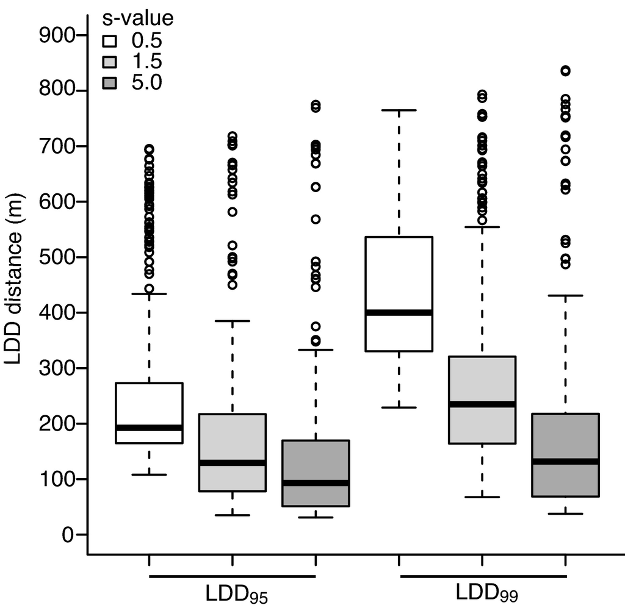

**FIGURE 2**

Trait-based estimates of long-distance dispersal (LDD) for 343 bird-dispersed woody plant species. The LDD of the plant species has been estimated based on three values of the trait-matching parameter (*s* = 0.5, 1.5 and 5.0), representing a range from a low to high degree of trait matching (Figure 1a), and by two percentiles of the distribution of modelled seed-dispersal distances for each plant species (LDD<sub>95</sub> and LDD<sub>99</sub>; Figure 1b). Boxes indicate the median (line) and the 25th and 75th percentiles across plant species. Whiskers indicate the data range, and circles denote outliers

The projected vertical temperature shift until 2070 increased with the magnitude of warming (Supporting Information Table S3). Under RCP 2.6 (strong mitigation scenario, projected temperature anomaly for the region relative to 1960–1990: range +1.29–1.83°C), the average projected vertical temperature shift was 248 ± 2 m (mean ± *SD*; *n* = 343 plant species). In comparison, under RCP 4.5 (moderate mitigation scenario, range +1.9–2.78°C), it approximated 367 ± 2 m, and under RCP 8.5 (high-emission scenario, range +3.06–4.26°C), it was estimated to be 566 ± 3 m. The corresponding required horizontal dispersal distances until 2070 were approximately fivefold larger (RCP 2.6, 1250 ± 193 m; RCP 4.5, 1846 ± 243 m; and RCP 8.5, 2851 ± 340 m).

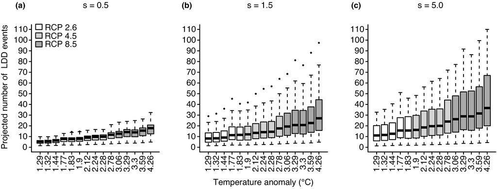

**FIGURE 3**

Projected number of long-distance dispersal (LDD) events required to track temperature change by 2070 for 343 bird-dispersed woody plant species. The number of LDD events is computed as the projected required horizontal dispersal distance divided by the simulated LDD of that plant species. The LDD was estimated based on a (a) low, (b) intermediate and (c) high degree of trait matching (*s* = 0.5, 1.5 and 5.0, respectively) and LDD<sub>95</sub>. Shown on the *x*-axis is the average projected anomaly in mean annual temperature until 2070 across the Manú gradient for each combination of emission scenario [representative concentration pathway (RCP) 2.6, 4.5 and 8.5] and climate model (five general circulation models). Boxes indicate the median (line) and 25th and 75th percentiles across plant species. Whiskers indicate the data range, and circles denote outliers

### 3.2 Degree of trait matching

Consistent with our first hypothesis, the projected number of LDD events required by 2070 increased substantially with an increasing degree of trait matching (Figure 3a–c). The degree of trait matching explained 20% of variation in LDD<sub>95</sub> (LMM: marginal *r*² = .2, conditional *r*² = .84, *F*<sub>2,684</sub> = 617.99, *p* < .001) and 40% of variation in LDD<sub>99</sub> (LMM: marginal *r*² = .4, conditional *r*² = .79, *F*<sub>2,684</sub> = 964.91, *p* < .001). Under a projected regional temperature anomaly of +1.29°C (low end of RCP 2.6), the mean projected number of LDD events required by 2070 was 5.05 ± 1.92 (mean ± *SD*; *n* = 343 plant species) in simulations based on a low degree of trait matching (*s* = 0.5; Figure 3a). In comparison, in simulations assuming a high degree of trait matching (*s* = 5.0; Figure 3c), the mean projected number of LDD events required by 2070 increased to 13.2 ± 8.35. The potential ability of plants to track temperature change decreased strongly in RCP scenarios with fewer mitigation measures. For instance, under a projected temperature anomaly of +2.78°C (high end of RCP 4.5), the mean projected number of LDD events required by 2070 was estimated to be 10.95 ± 4.08 in simulations assuming a low degree of trait matching (Figure 3a) and 28.66 ± 18.16 in simulations assuming a high degree of trait matching (Figure 3c). Interestingly, the projected number of LDD events required by 2070 varied far less among species in simulations with a low degree of trait matching. In simulations based on LDD<sub>99</sub> (Supporting Information Figure S3), qualitatively similar results were found.

### 3.3 Plant traits

Consistent with our second hypothesis, the projected number of LDD events required by 2070 was lower for large-fruited than for small-fruited plant species (Figure 4a,b). In simulations assuming an intermediate degree of trait matching (*s* = 1.5), fruit size explained 58% of the variation in LDD<sub>95</sub> (ANOVA: *r*<sup>2</sup> = .58, *F*<sub>1,170</sub> = 236, *p* < .001). Under RCP 2.6 (+1.29°C), the mean projected number of LDD events for large-fruited species was 3.7 ± 1.85 (mean ± *SD*; *n* = 86 plant species; Figure 4a). In comparison, the mean projected number of LDD events for small-fruited species was 10.2 ± 3.85 (Figure 4b). Under RCP 4.5 (+2.78°C), the mean projected number of LDD events was 8.04 ± 3.94 (Figure 4a) for large-fruited species and 22.07 ± 8.22 for small-fruited species (Figure 4b).

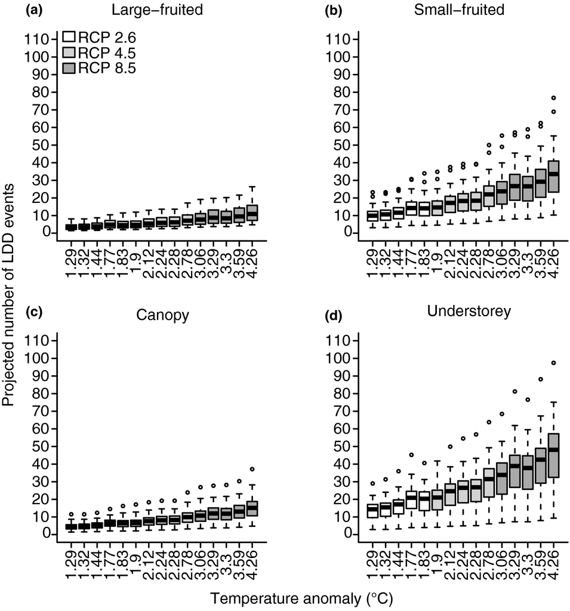

**FIGURE 4**

Projected number of long-distance dispersal (LDD) events required to track temperature change by 2070 for (a) large-fruited versus (b) small-fruited and (c) canopy versus (d) understorey bird-dispersed woody plant species (*n* = 86, respectively). The number of required LDD events equals the required horizontal dispersal distance divided by the LDD of that plant species. The LDD was estimated based on an intermediate degree of trait matching (*s* = 1.5) and LDD<sub>95</sub>. Shown on the *x*-axis is the average projected anomaly in mean annual temperature until 2070 across the Manú gradient for each combination of emission scenario [representative concentration pathway (RCP) 2.6, 4.5 and 8.5] and climate model (five general circulation models). Boxes indicate the median (line) and 25th and 75th percentiles across plant species. Whiskers indicate the data range, and circles denote outliers

Likewise, the projected number of LDD events was lower for canopy than for understorey plant species (Figure 4c,d). Assuming an intermediate degree of trait matching (*s* = 1.5), plant height explained 63% of the variation in LDD<sub>95</sub> (ANOVA: *r*<sup>2</sup> = .63, *F*<sub>1,170</sub> = 282.8, *p* < .001). Under RCP 2.6 (+1.29°C), the mean projected number of LDD events required by 2070 was 4.31 ± 1.77 (Figure 4c) for canopy species and 13.67 ± 4.85 (Figure 4d) for understorey species. Under RCP 4.5 (+2.78°C), the mean projected number of LDD events was 9.41 ± 3.77 for canopy species and 29.76 ± 10.5 for understorey species. Qualitatively similar differences between plant species with different traits were found for different degrees of trait matching (Supporting Information Figures S4 and S5) and LDD<sub>99</sub>.

## 4 DISCUSSION

With a new combination of trait-based approaches, we quantified the ability of bird-dispersed woody plant species to track projected vertical temperature shifts until 2070 on a tropical mountain. Our simulations suggest that the LDD of many plant species might be insufficient, because plants were projected to require several LDD events to track vertical temperature shifts by 2070, even under scenarios of strong and moderate mitigation of greenhouse gas emissions. Previous studies have shown that seed dispersal by mammals can help plant species to track temperature shifts on mountains (González-Varo et al., 2017; Naoe et al., 2016). In contrast, our simulations suggest that avian-mediated seed dispersal might be insufficient for plants to track their temperature niche on mountains in the near future. Our results are in line with the discrepancy between observed vertical range shifts of tropical tree genera and vertical temperature shifts on tropical mountains (Feeley et al., 2011). Importantly, our simulations also show that both the degree of trait matching and plant traits influence the extent to which plant species might lag behind climate change.

Our results imply that plants in seed-dispersal systems with a low degree of trait matching might be more resilient to climate change because they are better able to track temperature changes via dispersal. Differences in LDD between simulations with different degrees of trait matching were more pronounced for LDD<sub>99</sub> compared with LDD<sub>95</sub>, suggesting that especially, the probability of extreme dispersal events increases in generalized seed-dispersal systems. This is because large-bodied avian frugivores feed on a wider range of plant species in such systems, which increases the diversity of seed dispersers for small-fruited and understorey plant species and the probability of rare LDD events for these species (Sorensen et al., 2020). The similarity in seed dispersers across plant species also explains why differences among the dispersal abilities of plants are less pronounced under low compared with high trait-matching scenarios (Sorensen et al., 2020). In contrast, under high degrees of trait matching, the large-bodied bird species mostly feed on and disperse large fruits, making small-fruited plants less likely to track rapid temperature change. It has been found that seed-dispersal networks are less specialized at low latitudes than at high latitudes (Dalsgaard et al., 2017) and in the Afrotropics compared with the Neotropics (Dugger et al., 2019). Furthermore, the specialization of seed-dispersal networks can increase with elevation (Quitián et al., 2018) and is larger in the forest interior than at forest edges (Menke et al., 2012). This variability of specialization in seed-dispersal systems, in concert with the findings of our simulations, suggests that the ability of bird-dispersed plants to track climate change might vary substantially, both globally and locally.

A low degree of specialization is generally considered beneficial for species facing environmental change (Gallagher et al., 2015), and earlier work quantifying the susceptibility of species to climate change has focused on the habitat or dietary specialization of species (MacLean & Beissinger, 2017). In contrast, the effects of biotic specialization in complex interaction networks have been less thoroughly explored (Bascompte et al., 2019; Schleuning et al., 2016). Previous work suggests that biotic interactions with a low degree of specialization are functionally more redundant and more robust against extinction cascades resulting from the loss of interaction partners (Brodie et al., 2014). Our results imply that the specialization of seed-dispersal networks is not only important for mediating the risk of secondary extinctions, but might also have a functional influence on the ability of plants to track climate change.

We also found a greater ability of large-fruited and canopy plant species to track projected temperature shifts in comparison to small-fruited and understorey species. Differences in plant traits explained *c*. 60% of the variation in LDD distances among plant species. These pronounced differences between plants with different traits are related to the higher preference of large-sized avian frugivores with large beaks and pointed wings for large-fruited and canopy plant species (Shanahan & Compton, 2001). We found this effect in simulations with different degrees of trait matching. In line with our findings, fossil pollen data indicate that large-seeded plant assemblages have tracked rapid climate change more closely than small-seeded plant assemblages in the Late Quaternary (Knight et al., 2020). Likewise, large-seeded understorey plants have been observed to track contemporary climate change better than small-seeded ones (Ash et al., 2017). In addition to fruit size, plant height has also been shown to be positively associated with dispersal distance within and across dispersal modes (Thomson et al., 2011). This congruence between the predictions of our model and empirical data from past and current range shifts corroborates the realism of our model.

Fruit size and seed size, in addition to plant height, also impact other aspects of the demography and colonization potential of plants. Although fruit removal tends to be higher for small-seeded canopy plant species (Muñoz et al., 2016; Schleuning et al., 2011), seedling survival and recruitment probability are usually higher for large-seeded and understorey species (Moles & Westoby, 2004; Muñoz et al., 2016). Nevertheless, plant species with different traits usually achieve similar lifetime fitness because traits that promote a high dispersal ability usually imply a lower recruitment success, and vice versa (Terborgh et al., 2014). Our findings suggest that the checks and balances in such life-history trade-offs might be shifted towards large-fruited canopy species because these species have a higher ability to track changing temperatures in a quickly changing environment. Further studies are required to test the extent to which such indirect, animal-mediated effects on plant traits trigger changes in plant evolution and community structure under climate change (Nascimento et al., 2020; Sales et al., 2021).

The dispersal ability of plant species in response to climate warming might interact strongly with other drivers of global change. Defaunation and the subsequent downsizing of animal communities have been shown to affect large-fruited plant species severely (Dirzo et al., 2014). Specifically, the downsizing of frugivore communities can substantially reduce the LDD of bird-dispersed plants even if only a few large dispersers are lost (Donoso et al., 2020). Although large-fruited canopy plant species might be more likely to keep up with rapid climate change, this implies that they might quickly lose dispersal ability in defaunated ecosystems and that the conservation of functionally diverse communities of avian seed dispersers will be pivotal to promote tracking of climate shifts by plants. The effects of defaunation on seed dispersal could be accelerated further by the observed declines in disperser body size as a direct response to climate change (Weeks et al., 2020) and by projected losses of large frugivores under climate change (Sales et al., 2021).

By applying a new combination of simulation models parameterized with empirical occurrence and trait data, we shed light on how the degree of trait matching and plant traits might influence the ability of bird-dispersed plants to track projected temperature shifts over the coming decades. Such knowledge is highly relevant in light of rapid climate change because it can increase our understanding of which species might be better able to track climate change and which species might require assisted migration (Lenoir et al., 2020). Nevertheless, we acknowledge that our trait-based simulation approach has limitations. First, the simulations of plant–frugivore interactions could be refined further by accounting for species abundances along the elevational gradient and by considering additional plant traits, such as the nutritional content of fruits (González-Castro et al., 2015). Furthermore, the ongoing debate on mechanisms and possible niche shapes describing the probability of seed-dispersal interactions (Burns, 2013; González-Varo, Onrubia, et al., 2021) leaves room for future improvements of the trait-matching model, although previous work has shown that different types of niche shapes can yield similar findings in simulation studies of seed-dispersal distances (Donoso et al., 2017). Nevertheless, analyses of the relationships between traits and interaction probabilities in different seed-dispersal systems, based on empirical interaction data, are needed and could inform future modelling studies by adjusting the trait-matching model to different regional species pools. Second, our seed-dispersal model builds on a rather small empirical data source, and validation with more empirical seed-dispersal data would be desirable (Sorensen et al., 2020). A quantitative comparison of our simulation results with observed plant range shifts on tropical mountains (Feeley et al., 2011; Morueta-Holme et al., 2015) could be enlightening in future work. Moreover, our model is limited to bird-dispersed plants, but other animal vectors of seed dispersal, such as mammals, might provide longer dispersal distances and play a prominent role for plants to escape warming (González-Varo et al., 2017; Naoe et al., 2016). Finally, our projections consider a fixed time window until 2070 and do not account for differences in the generation times of plant species owing to a lack of such data for most of the studied plant species. Nevertheless, it is unlikely that woody plant species could undergo multiple LDD events by 2070 because most of them have long maturation and generation times, which slows down their ability to track climate change (Salguero-Gómez et al., 2015). Although we have not incorporated an explicit temporal component in our dispersal model, LDD events tend to occur infrequently (Nathan et al., 2008), and according to our simulations it is very unlikely that the rates of these events are large enough to match the projected timing of rapid warming.

Our study demonstrates a new way of using functional traits to project the ability of bird-dispersed plants to track temperature change. In a tropical mountain system, we find that avian seed dispersal appears to be insufficient for the large majority of woody plant species to track vertical temperature shifts over the next decades. Our study proposes a relatively simple trait-based tool to approximate the dispersal ability of bird-dispersed plant species and requires information only on plant–frugivore co-occurrences and functional plant and bird traits. The increasing availability of functional trait data of plants and birds globally can allow adjustment and parameterization of similar models for both lateral and vertical seed dispersal for many other types of avian seed-dispersal systems. Such trait-based dispersal models could prospectively be integrated into projection models of biodiversity in a rapidly changing world.

## ACKNOWLEDGMENTS

We thank T. Töpfer (Zoological Research Museum Alexander Koenig Bonn) for measuring the majority of bird specimens. R. van den Elzen (Zoological Research Museum Alexander Koenig Bonn), R. Prŷs-Jones and M. P. Adams (Natural History Museum Tring), G. Mayr (Senckenberg Museum Frankfurt) and R. Winkler (Natural History Museum Basel) provided access to bird collections. M. Hennen, J. Bates and D. Willard (Field Museum of Natural History Chicago) sent specimens, and J. V. Remsen and S. W. Cardiff (Louisiana State University Museum of Natural Science Baton Rouge) and D. Willard (Field Museum of Natural History Chicago) provided additional measurements. We also thank R. Diesener, S. Frahnert, C. Bracker, P.-R. Becker, J. Fjeldså, N. Krabbe and J. Mlíkovsky for information about collection holdings. Fieldwork at Manú was conducted under the permits 041-2010-AG-DGFFSDGEFFS, 008-2011-AG-DGFFS-DGEFFS, 01-C/C-2010SERNANP-JPNM and 01-2011-SERNANP-PNM-JEF and supported by a scholarship from the German Academic Exchange Service to D.M.D. D.M.D. acknowledges funding from the European Research Council (ERC) under the European Union's Horizon 2020 research and innovation programme (grant number 787638) and the Swiss National Science Foundation (grant number 173342), both awarded to C. H. Graham. W.D.K. acknowledges a Global Ecology grant from the University of Amsterdam Faculty Research Cluster. I.D. was funded by the Alexander von Humboldt Foundation and is now supported by the Balearic Government. S.A.F. was funded by the German Research Foundation (DFG; FR 3246/2-2) and the Leibniz Competition of the Leibniz Association (P52/2017). Finally, we are grateful to Renske E. Onstein and four anonymous reviewers for giving us valuable advice to improve the manuscript.

## CONFLICT OF INTEREST

The authors state no competing interests.

## BIOSKETCH

**Larissa Nowak** is interested in understanding how global change affects interacting species and how these effects are mediated by species functional traits. This study is part of her dissertation at Senckenberg Biodiversity and Climate Research Centre and Goethe University Frankfurt.

[figure not shown]

Online Version of Record before inclusion in an issue